# Project 3

Aj Averett

2022-07-05

# “How much explosive material remains in the soil?”

The following project will attempt to answer the question above.

# Background

The military is concerned about amount of explosives that remain in the soils of training ranges because soldiers are out on the training range and explosive residues are carcinogens (they cause cancer). Collecting a representative sample from the training ranges is difficult to do and researchers are continuing to work on developing, refining, and validating sampling methods.

The project below relies on assumptions and use of probability distributions. I will

- fit probability distributions to data
- create simulated samples from those fitted probability distributions, and
- use the fitted probability distributions to provide probability information about explosive residue in the surface soil of a training range.

The Environment Protection Agency (EPA) specifies regulatory levels of Nitroglycerin concentrations for human heath. For this project, we will use 10 mg/kg1 as the toxicity threshold for surface soil of this training range.

# The given data

The library, data4soils, contains the given data. Ng will be the measurements of soil toxicity.

```r
library(data4soils)
library(tidyverse)

Ng <- cfbp_fpjuliet$ng

Ng |> head() |> pander::pander()
```

*5.23*, *1.76*, *0.883*, *0.796*, *0.456* and *0.327* these are example measurements from the dataset.

# Models to be fitted from the data:

**Function $f_0(x)$, a uniform distribution.**
$$f_0(x; a,b) = \frac{1}{b-a}$$
$-\infty < a < x < b < \infty,\text{ and 0 otherwise.}$

**Function $f_1(x)$, a normal distribution.**
$$f_1(x; \mu,\sigma) = \frac{1}{\sqrt{2\pi
\sigma^2}}e^{-\frac{1}{2}\left(\frac{x-\mu}{\sigma}\right)^2}$$
$\mu > 0, \sigma >0 \text{ and } -\infty < x < \infty$

**Function $f_2(x)$, a gamma distribution.**
$$f_2(x; \alpha,\beta) =
\frac{\beta^{\alpha}}{\Gamma(\alpha)}x^{\alpha-1}e^{-\beta x}$$
$\alpha > 0, \beta > 0, x \geq 0,\text{ and 0 otherwise.}$

**Function $f_3(x)$, an exponential distribution.**
$$f_3(x; \lambda) = \lambda e^{-\lambda x}$$
$\lambda > 0, x \geq 0, \text{ and 0 otherwise.}$

# Fitting models

The models are fit through the method of moments:

1. Calculate the mean of the data.
2. Calculate the variance of the data.
3. Calculate the mean of the distribution as a function of the parameters of the distribution.
4. Calculate the variance of the distribution as a function of the parameters of the distribution.
5. Set the mean of the distribution equal to the mean of the data.
6. Set the variance of the distribution equal to the variance of the data.
7. Solve the system of equations for the parameter values. Note:

If the distribution (or model) has only one parameter, then skip steps 2, 4, and 6. Solve the equation you find in step 3. If the distribution (or model) has more than two parameters, calculate additional identifying characteristics of the distribution and data and set those quantities equal and solve the resulting system of equations. (It will be a system of more than two equations and two unknowns.)

# The fitted models

**Fitted model $f_0$, a uniform distribution.**

$$\begin{equation}
f_0(x; a = -2.947, b = 8.531) =
\left\{
\begin{array}{lr}
\frac{1}{(8.531)-(-2.947)}, & -\infty < a < x < b
< \infty\\
0, & \text{otherwise}
\end{array}
\right\}
\end{equation}$$

**Fitted model $f_1$, a normal distribution.**

$$f_1(x; \mu = 2.792, \sigma = 3.313) = \frac{1}{\sqrt{2\pi
(3.313)^2}}e^{-\frac{1}{2}\left(\frac{x-(2.792)}{3.313}\right)^2}$$

**Fitted model $f_2$, a gamma distribution.**

$$\begin{equation}
f_2(x; \alpha = 0.71, \beta = 0.254) =
\left\{
\begin{array}{lr}
\frac{0.254^{0.710}}{\Gamma(0.710)}x^{0.710-1}e^{-0.254 x},
& 0\leq x\\
0, & \text{otherwise}
\end{array}
\right\}
\end{equation}$$

**Fitted model $f_3$, an exponential distribution.**

$$\begin{equation}
f_3(x; \lambda = 0.358) =
\left\{
\begin{array}{lr}
0.358 e^{-0.358 x}, & 0\leq x\\
0, & \text{otherwise}
\end{array}
\right\}
\end{equation}$$

# Finding Probability

**Using an integral to calculate the probability that the amount of explosive in a sample will be between 0 mg/kg and 5 mg/kg**

**For the fitted model $f_0(x)$**

$$\int_0^5f_0(x)dx \approx 0.436$$

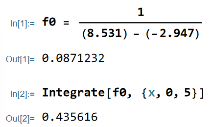

```r
knitr::include_graphics("p31.png")
```

**For the fitted model $f_3(x)$**

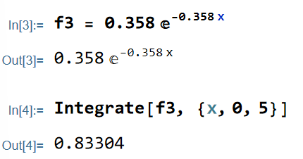

```r
knitr::include_graphics("p32.png")
```

## What does this mean in the context of the concentration of explosive in a soil sample?

**Function $f_1$**
$$\int_{-\infty}^b \left( \frac{1}{\sqrt{2\pi
(3.313)^2}}e^{-\frac{1}{2}\left(\frac{x-(2.792)}{3.313}\right)^2}
\right)=.99$$
Thus, $b = 10.4992$

```
#Mathematica
f1 = 1/Sqrt[2*Pi*(3.313)^2]*Exp[-(1/2) ((x - (2.792))/3.313)^2]
FindInstance[Integrate[f1, {x, -Infinity, b}] == .99, {b}, Reals]
```

$$\begin{equation}
f_3(x; \lambda = 0.358) =
\left\{
\begin{array}{lr}
0.358 e^{-0.358 x}, & 0\leq x\\
0, & \text{otherwise}
\end{array}
\right\}
\end{equation}$$

$$\int_{0}^b \left( 0.358 e^{-0.358 x} \right)=.99$$

Thus, $b = 12.8636$

```
#Mathematica
f3 = 0.358 E^(-0.358*x)
Solve[Integrate[f3, {x, 0, b}] == .99, {b}]
```

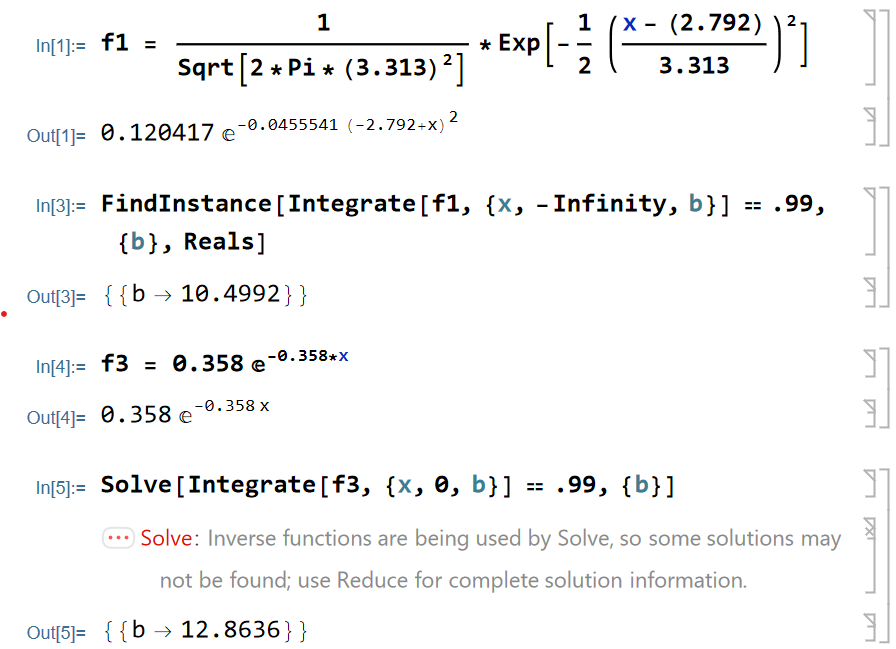

```r
knitr::include_graphics("p33.png")
```

# Finding the probability that the amount of explosive in a sample will be more than 10 mg/kg?

**Function $f_0$**

Since the domain for $f_0$ is restricted from a to b, and 10 is greater than b, the probability is zero.

$$\begin{equation}
f_0(x; a = -2.947, b = 8.531) =
\left\{
\begin{array}{lr}
\frac{1}{(8.531)-(-2.947)}, & -\infty < a < x < b
< \infty\\
0, & \text{otherwise}
\end{array}
\right\}
\end{equation}$$

```
#Mathematica
Integrate[0, {x, 10, Infinity}]
```

Probability is 0 according to model $f_0$

$$\int_{10}^{\infty}\left( 0 \right)=0 \%$$

**Function $f_1$**

```
#Mathematica
f1 = 1/Sqrt[2*Pi*(3.313)^2]*Exp[-(1/2) ((x - (2.792))/3.313)^2]
Re[Integrate[f1, {x, 10, Infinity}]]
```

Probability is 0.014 according to model $f_1$

$$\int_{10}^{\infty}\left( \frac{1}{\sqrt{2\pi
(3.313)^2}}e^{-\frac{1}{2}\left(\frac{x-(2.792)}{3.313}\right)^2}
\right)\approx1.48 \%$$

**Function $f_2$**

```
#Mathematica
  f2 = 0.254^0.710/Gamma[0.710]*x^(0.710 - 1)*E^(-0.254*x)
  Integrate[f2, {x, 10, Infinity}]
```

Probability is 0.0429821 according to model $f_2$

**Function $f_3$**

```
#Mathmatica
f3 = 0.358 E^(-0.358*x)
Integrate[f3, {x, 10, Infinity}]
```

$$\int_{10}^{\infty}\left( 0.358 e^{-0.358 x} \right)\approx 2.78 \%$$

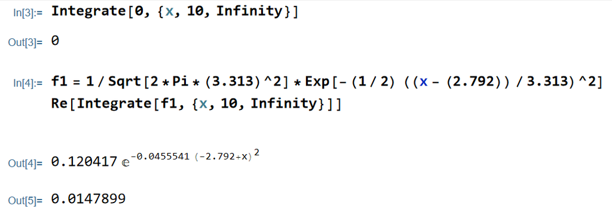

```r
knitr::include_graphics("p3a.png")
```

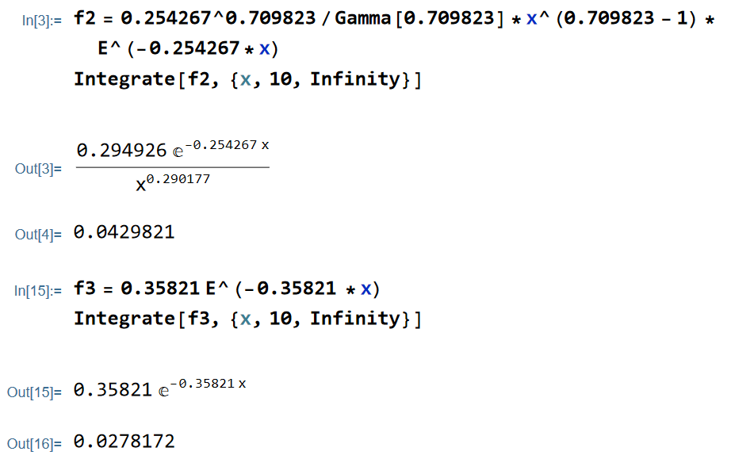

```r
knitr::include_graphics("corrections.png")
```

Thus, the probability is probably quite low.

Depending on the type of distribution, we will get different answers. For example, the uniform distribution does not represent reality since the probability is the same between the respective a and b values. This does not represent reality since the probability of the Ng concentration will change as this value it gets farther away from the mean. The normal distribution is not a good fit as well since the domain is not restricted to only non-negative values. This allows for the possibility to calculate a non-negative probability for the impossibility of non-negative concentrations of Ng.

On the other hand, the gamma and exponential distribution seem to be better models since the domain is restricted to non-negative numbers. This means that when the mean (and possibly variance) is set to the respective statistics of the model, it is a better fit.

# The answer

The models $f_0$ is not representative of reality because the uniform distribution is unlike the actual probability of what we would expect.

I would say that the probability that the soil is toxic is roughly 3-4 percent.

# Reflection

For this project, I have learned many key concepts in relation to calculus and probability. I have tried to make this cohesive and easy to read. This was a very fun project to work on.

I would like to remember the key concepts including probability, how to calculate the expected value and variance of a continuous distribution. I found the information on integrals very interesting as the creator of integrals used limits in an unexpected way to find the area of any function.

I was originally thinking of not doing this project, however encouragement from my friend persuaded me to dedicate myself to finish this project. I feel like I have working on motivation and self-direction as I actually had to finish. I also believe this allowed me to exercise my willingness to learn because there were several concpets I may not have learned fully at first, but then learned eventually with help from the teacher and others.